# Data Visualization Mini-Project 2: An Analysis of Billboard Summer Hits

Gregory Bateham gbateham9459@floridapoly.edu

2025-07-06

## 1. Introduction and Planning

My report explores the “All Billboard Summer Hits” dataset, focusing on the quantitative audio features of songs that have defined summers past. The goal I set for myself was to practice data wrangling and visualization techniques to uncover patterns in the data and tell a story about how the sound of summer hits has evolved over time.

#### Original Plan

My plan is to create three visualizations to answer the following questions: 1. **What is the relationship between a song’s energy and its danceability?** I plan to make an interactive scatter plot for this, colored by decade, to see how this relationship has changed over time. 2. **How has the “sound” of summer evolved?** To meet the project’s spatial requirement, I’ll create a conceptual “map of summer music,” assigning key decades to cities whose music scenes were influential during those periods (e.g., 1970s Disco to New York). 3. **Can we predict a song’s mood?** I will build a linear model to predict `valence` using other audio features and visualize the model’s coefficients to see which factors are most important for a “happy” sounding summer hit.

## 2. Data Cleaning and Preparation

The first step is to load the necessary libraries and the dataset.

```r
library(tidyverse)
library(plotly)    # For creating interactive plots
library(leaflet)   # For creating interactive maps
library(broom)     # For tidying model output

billboard_df <- read_csv("../data/all_billboard_summer_hits.csv")

if (!"speechiness" %in% names(billboard_df) && "speehiness" %in% names(billboard_df)) {
  billboard_df <- rename(billboard_df, speechiness = speehiness)
}

songs_clean <- billboard_df %>%
  # Select and rename columns for clarity and relevance
  select(
    year, track_name, artist_name,
    danceability, energy, loudness, speechiness, acousticness,
    instrumentalness, liveness, valence, tempo, duration_ms
  ) %>%
  # Create a 'decade' column for grouping
  mutate(
    decade = floor(year / 10) * 10,
    decade = paste0(decade, "s")
  ) %>%
  # Convert decade to a factor for plotting
  mutate(decade = as.factor(decade)) %>%
  # Remove duplicates, keeping the first instance of each track
  distinct(track_name, artist_name, .keep_all = TRUE)

# Glimpse the cleaned data
glimpse(songs_clean)
```

```
## Rows: 600
## Columns: 14
## $ year             <dbl> 1958, 1958, 1958, 1958, 1958, 1958, 1958, 1958, 1958,…
## $ track_name       <chr> "Nel blu dipinto di blu", "Poor Little Fool", "Patric…
## $ artist_name      <chr> "Domenico Modugno", "Ricky Nelson", "Pérez Prado", "T…
## $ danceability     <dbl> 0.518, 0.543, 0.541, 0.408, 0.554, 0.679, 0.663, 0.68…
## $ energy           <dbl> 0.060, 0.332, 0.676, 0.397, 0.189, 0.279, 0.619, 0.55…
## $ loudness         <dbl> -14.887, -11.573, -7.988, -12.536, -14.277, -10.386, …
## $ speechiness      <dbl> 0.0441, 0.0317, 0.1350, 0.0300, 0.0279, 0.0384, 0.033…
## $ acousticness     <dbl> 0.9870, 0.6690, 0.1880, 0.8730, 0.9150, 0.6450, 0.336…
## $ instrumentalness <dbl> 7.87e-06, 0.00e+00, 8.03e-01, 0.00e+00, 1.37e-05, 0.0…
## $ liveness         <dbl> 0.1610, 0.1340, 0.1230, 0.2800, 0.1320, 0.1180, 0.062…
## $ valence          <dbl> 0.336, 0.795, 0.911, 0.697, 0.214, 0.854, 0.979, 0.86…
## $ tempo            <dbl> 127.870, 154.999, 76.231, 72.615, 136.714, 117.287, 1…
## $ duration_ms      <dbl> 216373, 153933, 128360, 162773, 165293, 161253, 15060…
## $ decade           <fct> 1950s, 1950s, 1950s, 1950s, 1950s, 1950s, 1950s, 1950…
```

## 3. Visualizations and Findings

Here, I present the three visualizations created from the cleaned data, each telling a part of the story of summer hits.

### Visualization 1: Interactive - Energy and Danceability Through the Decades

**Story**: This plot explores the classic relationship between `energy` and `danceability`. By coloring the points by decade, I’ll be able to see if the sonic signature of a “danceable hit” has changed over time.

```r
# Sample the data to avoid overplotting if the dataset is large
set.seed(42) # for reproducibility
sample_size <- min(nrow(songs_clean), 2000)
songs_sample <- songs_clean %>% sample_n(sample_size)

p <- ggplot(songs_sample, aes(x = energy, y = danceability, color = decade,
                          # Custom data for the hover text in plotly
                          text = paste("Track:", track_name,
                                       "<br>Artist:", artist_name,
                                       "<br>Year:", year))) +
  geom_point(alpha = 0.7, size = 1.5) +
  labs(
    title = "Energy vs. Danceability in Summer Hits by Decade",
    subtitle = "The positive correlation is timeless, but each decade has its own cluster",
    x = "Energy",
    y = "Danceability",
    color = "Decade"
  ) +
  theme_minimal() +
  theme(legend.position = "bottom")

# Convert to an interactive plotly object
ggplotly(p, tooltip = "text")
```

[interactive chart not shown]

### Visualization 2: Spatial - A Conceptual Map of Summer Music Eras

**Story**: This visualization I coded creates a conceptual map to tell a story about the “sound” of different eras. It assigns major decades to cities famous for influential music scenes during those times, creating an interactive map that connects sounds to places and times.

```r
# 1. Create a summary data frame by decade
decade_summary <- songs_clean %>%
  group_by(decade) %>%
  summarise(
    track_count = n(),
    avg_valence = mean(valence, na.rm = TRUE),
    avg_energy = mean(energy, na.rm = TRUE)
  ) %>%
  ungroup()

# 2. Manually create the spatial data by assigning cities to decades
decade_locations <- decade_summary %>%
  # Filter out decades with too few songs for a cleaner map
  filter(track_count > 10) %>%
  mutate(
    city = case_when(
      decade == "1960s" ~ "London, UK",
      decade == "1970s" ~ "New York, USA",
      decade == "1980s" ~ "Los Angeles, USA",
      decade == "1990s" ~ "Atlanta, USA",
      decade == "2000s" ~ "Stockholm, Sweden", # Max Martin Pop Factory
      decade == "2010s" ~ "Global/Online"
    ),
    lat = case_when(
      decade == "1960s" ~ 51.5074,
      decade == "1970s" ~ 40.7128,
      decade == "1980s" ~ 34.0522,
      decade == "1990s" ~ 33.7490,
      decade == "2000s" ~ 59.3293,
      decade == "2010s" ~ 20.0
    ),
    lng = case_when(
      decade == "1960s" ~ -0.1278,
      decade == "1970s" ~ -74.0060,
      decade == "1980s" ~ -118.2437,
      decade == "1990s" ~ -84.3880,
      decade == "2000s" ~ 18.0686,
      decade == "2010s" ~ 0
    )
  ) %>%
  # Create popup text
  mutate(popup_text = paste(
    "<b>Decade:</b>", decade,
    "<br><b>Conceptual Home:</b>", city,
    "<br><b>Avg. Mood (Valence):</b>", round(avg_valence, 2),
    "<br><b>Avg. Energy:</b>", round(avg_energy, 2)
  ))

# 3. Create the leaflet map
leaflet(decade_locations) %>%
  addProviderTiles(providers$CartoDB.Positron, options = providerTileOptions(minZoom = 2, maxZoom=6)) %>%
  addCircleMarkers(
    lng = ~lng, lat = ~lat,
    popup = ~popup_text,
    radius = ~sqrt(track_count)/2, # Scale radius by number of hits
    color = "darkred",
    stroke = FALSE,
    fillOpacity = 0.7
  ) %>%
  setView(lng = -30, lat = 35, zoom = 2) %>%
  addControl("<h4>Conceptual Map of Summer Hit Eras</h4>", position = "topright")
```

[interactive chart not shown]

### Visualization 3: Model - Predicting a Summer Hit’s Mood (Valence)

**Story**: What makes a summer hit sound “happy”? This visualization I created builds a linear model to predict a song’s `valence` (musical positiveness) from its other attributes. I’ll then plot the coefficients to see which features are the most powerful predictors.

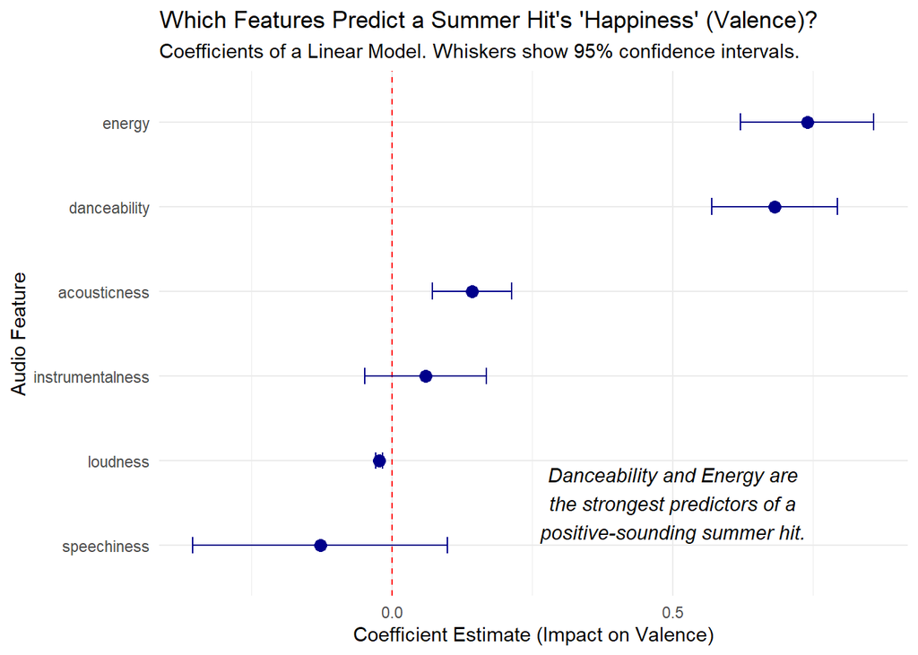

```r
# 1. Build the linear model
valence_model <- lm(
  valence ~ danceability + energy + loudness + speechiness + acousticness + instrumentalness,
  data = songs_clean
)

# 2. Tidy the model output
model_tidy <- tidy(valence_model, conf.int = TRUE) %>%
  filter(term != "(Intercept)")

# 3. Create the coefficient plot
# Annotation for the plot
annotation_text <- "Danceability and Energy are the strongest predictors of a positive-sounding summer hit."

ggplot(model_tidy, aes(x = estimate, y = reorder(term, estimate))) +
  geom_vline(xintercept = 0, color = "red", linetype = "dashed") +
  geom_point(color = "darkblue", size = 3) +
  geom_errorbarh(aes(xmin = conf.low, xmax = conf.high), height = 0.2, color = "darkblue") +
  labs(
    title = "Which Features Predict a Summer Hit's 'Happiness' (Valence)?",
    subtitle = "Coefficients of a Linear Model. Whiskers show 95% confidence intervals.",
    x = "Coefficient Estimate (Impact on Valence)",
    y = "Audio Feature"
  ) +
  theme_minimal() +

  annotate("text", x = 0.5, y = 1.5, label = str_wrap(annotation_text, 35), hjust = 0.5, fontface = "italic")
```

## 4. Discussion and Conclusion

My project set out to explore the audio characteristics of Billboard Summer Hits, guided by a plan to create three distinct visualizations: an interactive scatter plot, a spatial map, and a model coefficient plot. My process began with essential data preparation, which involved loading the data, selecting relevant features, and engineering a `decade` variable to enable historical analysis. This foundational work was crucial for my subsequent visualizations.

#### Challenges and Design Principles

As I worked on this project, key principles of data visualization were applied. Clarity and simplicity were prioritized by using `theme_minimal()` to maximize the data-ink ratio. **Interactivity** was leveraged via `plotly` and `leaflet` to encourage user exploration and engagement. Clear annotations and labels were used on all plots to guide interpretation, with the model plot featuring a direct text annotation to ensure the main finding was unmissable. These decisions transform the charts from simple data displays into effective tools for communication and storytelling.

#### Future Directions

While this analysis yielded clear insights, there are many additional avenues for exploration. A time-series analysis could plot how the average of each audio feature has trended year-over-year, revealing more granular shifts in musical tastes. Furthermore, unsupervised clustering algorithms like K-Means could be applied to the audio features to discover natural, data-driven “genres” or “types” of summer hits, which may differ from traditional genre labels. These advanced techniques could uncover even deeper patterns in what makes a song a timeless summer hit.